# 🤖 Machine Learning

Como subcampo de la IA, el Machine Learning se centra en la creación de algoritmos y modelos estadísticos que permiten a las computadoras mejorar su rendimiento en tareas específicas mediante el aprendizaje de los datos.

A diferencia de la programación tradicional, los sistemas de aprendizaje automático adquieren conocimiento de los datos, detectan patrones y toman decisiones o predicciones.

El aprendizaje automático ha cobrado una enorme importancia en diversos sectores, como la salud, las finanzas, el marketing y la tecnología. Ha revolucionado la toma de decisiones, la automatización de procesos y la extracción de información de grandes conjuntos de datos.

Sus principales beneficios incluyen la automatización, el análisis predictivo, la personalización, el diagnóstico médico y el procesamiento del lenguaje natural.

# 📈**Tipos de Aprendizaje en ML**

En **Machine Learning** existen diferentes formas en que una máquina puede aprender a partir de los datos. Los tres tipos principales son: **aprendizaje supervisado, no supervisado y por refuerzo**.

## **Aprendizaje Supervisado - Supervise Learning**

En este enfoque, el modelo aprende a partir de un conjunto de datos que incluye **entradas y salidas conocidas**. Es decir, el sistema recibe ejemplos con las respuestas correctas y ajusta sus predicciones para acercarse a esas respuestas.

- Un modelo que aprende a clasificar correos electrónicos como *spam* o *no spam*, usando ejemplos previamente etiquetados.
- Reconocimiento de voz: Un sistema que aprende a transcribir audio a texto, entrenado con grabaciones de voz y sus transcripciones correctas.
- Predicción del clima: Un modelo que, con datos históricos (temperatura, humedad, presión), predice si mañana lloverá o no.

Algunos de los importantes algoritmos de aprendizaje supervizado son:

- Linear Regression
- Logistic Regression
- Decision Trees
- Random Forest
- Support Vector Machines (SVM)
- Naive Bayes
- Gradient Boosting Machines
- Adaptive Learning Algorithms

## **Aprendizaje No Supervisado - Unsupervised learning**

Aquí, los datos **no tienen etiquetas**; el objetivo es encontrar patrones, estructuras o relaciones ocultas. El modelo organiza o agrupa la información por sí mismo.

- Un algoritmo que agrupa clientes en un supermercado según sus hábitos de compra, sin que exista una categoría predefinida.
- Segmentación de mercado: Una empresa usa datos de consumo para agrupar clientes en perfiles (ejemplo: “compradores frecuentes”, “ocasionales”, “de lujo”), sin etiquetas predefinidas.
- Compresión de imágenes: Algoritmos que reducen el tamaño de una imagen encontrando patrones de redundancia sin necesidad de ejemplos previos.

Algunos de los más importantes algoritmos de aprendizaje no supervisado son:

- Clustering
  - Clustering Algorithms
  - K-Means
  - DBSCAN
  - Hierarchical Cluster Analysis (HCA)
- Anomaly detection and novelty detection
  - One-class SVM
  - Isolation Forest
  - Hidden Markov Models (HMM)
  - K- Nearest Neighbors (KNN)
- Visualization and dimensionality reduction
  - Principal Component Analysis (PCA)
  - Kernel PCA
  - Locally Linear Embedding (LLE)
  - t-Distributed Stochastic Neighbor Embedding (t-SNE)
- Association rule learning
  - Apriori
  - Eclat

## **Aprendizaje por Refuerzo - Reinforcement Learning**

En este caso, el modelo aprende mediante **prueba y error**, recibiendo recompensas o penalizaciones por las acciones que realiza en un entorno. Su meta es encontrar la mejor estrategia para maximizar la recompensa.

- Un robot que aprende a caminar recibiendo puntos positivos cuando avanza y negativos cuando se cae.
- Videojuegos: Un agente que aprende a jugar a Pac-Man tomando decisiones en tiempo real, recibiendo puntos por comer frutas y evitando perder vidas.
- Robótica industrial: Un brazo robótico que aprende a ensamblar piezas mediante prueba y error, optimizando movimientos para reducir errores y maximizar eficiencia.

```python
from graphviz import Source

mapa = """
digraph MapaConceptualIA {
    graph [rankdir=TB, fontsize=8];

    node [shape=box, style="rounded,filled", fillcolor=white, fontname="Helvetica"];

    AI [label="INTELIGENCIA ARTIFICIAL\nCiencia que permite a las computadoras imitar la inteligencia humana.", color=green];
    ML [label="MACHINE LEARNING
    \nSubconjunto de la IA que permite a las máquinas mejorar con la experiencia.", color=red];

    SUP [label="APRENDIZAJE SUPERVISADO
    \nEntrenamiento con datos de
    entrada/salida etiquetados.", color=black];

    UNSUP [label="APRENDIZAJE NO SUPERVISADO
    \nEntrenamiento sin datos etiquetados.
    \nBusca patrones ocultos.", color=black];

    RL [label="APRENDIZAJE POR REFUERZO
    \nAlgoritmos que toman acciones para maximizar
    la recompensa acumulada.", color=black];

    CLAS [label="CLASIFICACIÓN", color=black];
    CLUS1 [label="AGRUPAMIENTO (Clustering)", color=black];
    CLUS2 [label="AGRUPAMIENTO (Clustering)", color=black];

    # Conexiones principales
    AI -> ML;
    ML -> SUP;
    ML -> UNSUP;
    ML -> RL;

    # Subcategorías
    SUP -> CLAS -> CLUS1;
    UNSUP -> CLUS2;
}
"""

# Mostrar el diagrama en Jupyter
Source(mapa)
```

[figure not shown]

**Similitudes:**

- Los tres métodos buscan que la máquina aprenda de la experiencia.
- Todos requieren datos o interacciones con el entorno.

**Diferencias:**

- El supervisado usa **datos con respuestas correctas**.
- El no supervisado trabaja con **datos sin etiquetas** para descubrir patrones.
- El reforzado aprende a través de **acciones, recompensas y penalizaciones**.

Otros algoritmos de Machine Learning

- Deep Learning and Neural Networks:
  - Recurrent Neural Networks (RNN)
  - Long Short-Term Memory (LSTM)
  - Convolutional Neural Networks (CNN)
  - Deep Q Networks (DQN)
- Transfer Learning Algorithms:
  - VGG (Visual Geometry Group)
  - ResNet (Residual Networks)
  - Inception Networks
  - BERT (Bidirectional Encoder Representations from Transformers)
  - GPT (Generative Pre-trained Transformer)
- Explainable Al Algorithms:
  - LIME (Local Interpretable Model-agnostic Explanations)
  - SHAP (SHapley Additive exPlanations)
  - ELI5 (Explain Like I'm 5)
  - Anchors (High-Precision Model-Agnostic Explanations)

# 🧠 **Principales desafíos del Machine Learning**

En resumen, dado la tarea principal es seleccionar un algoritmo de aprendizaje y entrenarlo con datos, existen varios factores que pueden hacer fallar este proceso los cuales son los datos incorrectos o un algoritmo incorrecto.

## Problemas en los datos

- **Cantidad insuficiente de datos de entrenamiento:** El aprendizaje automático aún no está del todo desarrollado; se necesitan muchos datos para que la mayoría de sus algoritmos funcionen correctamente. Incluso para problemas muy sencillos, se suelen necesitar miles de ejemplos, y para problemas complejos como el reconocimiento de imágenes o de voz, pueden necesitarse millones de ejemplos.

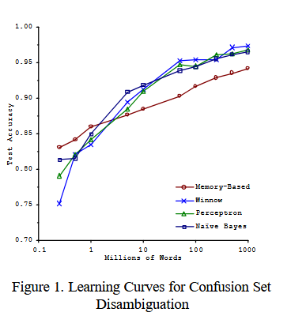

**Tomado de: Banko, Michele and Brill, Eric. Scaling to Very Very Large Corpora for Natural Language Disambiguation, 2001 (https://dl.acm.org/doi/10.3115/1073012.1073017)**

- **Datos de entrenamiento no representativos:** Para generalizar correctamente, es fundamental que los datos de entrenamiento sean representativos de los nuevos casos a los que se desea generalizar. Esto se aplica tanto al aprendizaje basado en instancias como al aprendizaje basado en modelos.

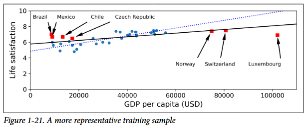

**Tomado de: Géron, Aurélien. Hands-On Machine Learning with Scikit-Learn, Keras, and TensorFlow**

Al utilizar un conjunto de entrenamiento no representativo, entrenamos un modelo que probablemente no realice predicciones precisas, especialmente para países muy pobres y muy ricos. Es crucial utilizar un conjunto de entrenamiento que sea representativo de los casos a los que se desea generalizar. Esto suele ser más difícil de lo que parece: si la muestra es demasiado pequeña, se obtendrá ruido de muestreo (es decir, datos no representativos debido al azar), pero incluso muestras muy grandes pueden no ser representativas si el método de muestreo es defectuoso. Esto se llama sesgo de muestreo.

- **Datos de baja calidad:** datos de entrenamiento llenos de errores, valores atípicos y ruido (por ejemplo, debido a mediciones de baja calidad).
- **Datos con Características Irrelevantes:** Como dice el refrán: basura entra, basura sale. El sistema solo podrá aprender si los datos de entrenamiento contienen suficientes características relevantes y no demasiadas irrelevantes.

### Problemas en los Algoritmos

- **Sobreajuste de los datos de entrenamiento:** significa que el modelo funciona bien con los datos de entrenamiento, pero no generaliza bien.
- **Subajuste de los datos de entrenamiento:** ocurre cuando el modelo es demasiado simple para comprender la estructura subyacente de los datos. las principales opciones para solucionar este problema:
  - Seleccionar un modelo más potente, con más parámetros.
  - Incorporar mejores características al algoritmo de aprendizaje (ingeniería de características).
  - Reducir las restricciones del modelo.

## Problemas de hardware y software

Los departamentos de TI se enfrentan a retos de hardware y software a la hora de respaldar el entrenamiento de modelos de ML. Entre los posibles obstáculos se encuentran disponer de suficiente potencia informática y capacidad de almacenamiento, recursos de datos y herramientas de compatibilidad e integración para llevar un proyecto hasta su finalización.

## Problemas en la contratación de personal calificado

Para desarrollar, gestionar e iterar el entrenamiento de modelos de ML se necesitan personas con conocimientos especializados en distintas disciplinas técnicas.

- Demanda de talentos
- Falta de profesionales capacitados en IA

## Problemas en la gestión de proyectos de ML

Los proyectos de IA empresarial pueden ser costosos y requerir muchos recursos. Más allá de las preocupaciones inmediatas de desarrollo de modelos, selección de fuentes de datos y entrenamiento de modelos de IA, la gestión requiere un delicado equilibrio de supervisión financiera, tecnológica y de programación.

- Fallas de comunicación
- Expectativas desalineadas

### En Resumen

- El Machine Learning consiste en lograr que las máquinas mejoren en alguna tarea aprendiendo de los datos, en lugar de tener que codificar reglas explícitamente.
- Existen muchos tipos diferentes de sistemas de aprendizaje automático: supervisados o no, por lotes o en línea, basados en instancias o en modelos.
- En un proyecto de aprendizaje automático, se recopilan datos en un conjunto de entrenamiento y se alimenta este conjunto a un algoritmo de aprendizaje.
  - Si el algoritmo se basa en modelos, ajusta algunos parámetros para ajustar el modelo al conjunto de entrenamiento (es decir, para realizar buenas predicciones sobre el propio conjunto de entrenamiento) y, con suerte, también podrá realizar buenas predicciones en nuevos casos.
  - Si el algoritmo se basa en instancias, simplemente aprende los ejemplos de memoria y los generaliza a nuevas instancias utilizando una medida de similitud para compararlas con las instancias aprendidas.
- El sistema no funcionará bien si el conjunto de entrenamiento es demasiado pequeño, si los datos no son representativos, si presentan ruido o si están contaminados con características irrelevantes (basura entrante, basura saliente).
- Por último, el modelo no debe ser ni demasiado simple (en cuyo caso se subajustará) ni demasiado complejo (en cuyo caso se sobreajustará).

# 🧾 Bibliografía y material de apoyo

- C. Huyen, Designing machine learning systems. ” O’Reilly Media, Inc.”, 2022. [Designing machine learning systems](https://github.com/chiphuyen/dmls-book/blob/main/README.md)
- Algorithmia, “2020 state of enterprise machine learning,” 2020.
- [AI Index Report](https://hai.stanford.edu/ai-index)
- [3Blue1Brown](https://www.youtube.com/@3blue1brown)
- [Building A Generative AI Platform](https://huyenchip.com/2024/07/25/genai-platform.html)
- [Awful AI](https://github.com/daviddao/awful-ai?tab=readme-ov-file)